# Ch13 Relational Data

```r
library(tidyverse)
library(tidyverse)
library(nycflights13)
```

For nycflights13:

flights connects to planes via a single variable, tailnum.

flights connects to airlines through the carrier variable.

flights connects to airports in two ways: via the origin and dest variables.

flights connects to weather via origin (the location), and year, month, day and hour (the time).

| year | month | day | dep_time | sched_dep_time | dep_delay | arr_time | sched_arr_time | arr_delay | carrier | flight | tailnum | origin | dest | air_time | distance | hour | minute | time_hour |
| --- | --- | --- | --- | --- | --- | --- | --- | --- | --- | --- | --- | --- | --- | --- | --- | --- | --- | --- |
| 2013 | 1 | 1 | 517 | 515 | 2 | 830 | 819 | 11 | UA | 1545 | N14228 | EWR | IAH | 227 | 1400 | 5 | 15 | 2013-01-01 05:00:00 |
| 2013 | 1 | 1 | 533 | 529 | 4 | 850 | 830 | 20 | UA | 1714 | N24211 | LGA | IAH | 227 | 1416 | 5 | 29 | 2013-01-01 05:00:00 |
| 2013 | 1 | 1 | 542 | 540 | 2 | 923 | 850 | 33 | AA | 1141 | N619AA | JFK | MIA | 160 | 1089 | 5 | 40 | 2013-01-01 05:00:00 |
| 2013 | 1 | 1 | 544 | 545 | -1 | 1004 | 1022 | -18 | B6 | 725 | N804JB | JFK | BQN | 183 | 1576 | 5 | 45 | 2013-01-01 05:00:00 |
| 2013 | 1 | 1 | 554 | 600 | -6 | 812 | 837 | -25 | DL | 461 | N668DN | LGA | ATL | 116 | 762 | 6 | 0 | 2013-01-01 06:00:00 |
| 2013 | 1 | 1 | 554 | 558 | -4 | 740 | 728 | 12 | UA | 1696 | N39463 | EWR | ORD | 150 | 719 | 5 | 58 | 2013-01-01 05:00:00 |
| 2013 | 1 | 1 | 555 | 600 | -5 | 913 | 854 | 19 | B6 | 507 | N516JB | EWR | FLL | 158 | 1065 | 6 | 0 | 2013-01-01 06:00:00 |
| 2013 | 1 | 1 | 557 | 600 | -3 | 709 | 723 | -14 | EV | 5708 | N829AS | LGA | IAD | 53 | 229 | 6 | 0 | 2013-01-01 06:00:00 |
| 2013 | 1 | 1 | 557 | 600 | -3 | 838 | 846 | -8 | B6 | 79 | N593JB | JFK | MCO | 140 | 944 | 6 | 0 | 2013-01-01 06:00:00 |
| 2013 | 1 | 1 | 558 | 600 | -2 | 753 | 745 | 8 | AA | 301 | N3ALAA | LGA | ORD | 138 | 733 | 6 | 0 | 2013-01-01 06:00:00 |

[output cut: 990 more lines]

13.2.1 Exercises Imagine you wanted to draw (approximately) the route each plane flies from its origin to its destination. What variables would you need? What tables would you need to combine?

I forgot to draw the relationship between weather and airports. What is the relationship and how should it appear in the diagram?

weather$origin and airports$faa

weather only contains information for the origin (NYC) airports. If it contained weather records for all airports in the USA, what additional relation would it define with flights?

the foreign keys that would be added to flights would be year, mon, day etc..

We know that some days of the year are “special”, and fewer people than usual fly on them. How might you represent that data as a data frame? What would be the primary keys of that table? How would it connect to the existing tables?

holiday or special date as chr variable, date as date variable, primary keys would be the holiday

13.3.1 1.

| key | year | month | day | dep_time | sched_dep_time | dep_delay | arr_time | sched_arr_time | arr_delay | carrier | flight | tailnum | origin | dest | air_time | distance | hour | minute | time_hour |
| --- | --- | --- | --- | --- | --- | --- | --- | --- | --- | --- | --- | --- | --- | --- | --- | --- | --- | --- | --- |
| 1 | 2013 | 1 | 1 | 517 | 515 | 2 | 830 | 819 | 11 | UA | 1545 | N14228 | EWR | IAH | 227 | 1400 | 5 | 15 | 2013-01-01 05:00:00 |
| 2 | 2013 | 1 | 1 | 533 | 529 | 4 | 850 | 830 | 20 | UA | 1714 | N24211 | LGA | IAH | 227 | 1416 | 5 | 29 | 2013-01-01 05:00:00 |
| 3 | 2013 | 1 | 1 | 542 | 540 | 2 | 923 | 850 | 33 | AA | 1141 | N619AA | JFK | MIA | 160 | 1089 | 5 | 40 | 2013-01-01 05:00:00 |
| 4 | 2013 | 1 | 1 | 544 | 545 | -1 | 1004 | 1022 | -18 | B6 | 725 | N804JB | JFK | BQN | 183 | 1576 | 5 | 45 | 2013-01-01 05:00:00 |
| 5 | 2013 | 1 | 1 | 554 | 600 | -6 | 812 | 837 | -25 | DL | 461 | N668DN | LGA | ATL | 116 | 762 | 6 | 0 | 2013-01-01 06:00:00 |
| 6 | 2013 | 1 | 1 | 554 | 558 | -4 | 740 | 728 | 12 | UA | 1696 | N39463 | EWR | ORD | 150 | 719 | 5 | 58 | 2013-01-01 05:00:00 |
| 7 | 2013 | 1 | 1 | 555 | 600 | -5 | 913 | 854 | 19 | B6 | 507 | N516JB | EWR | FLL | 158 | 1065 | 6 | 0 | 2013-01-01 06:00:00 |
| 8 | 2013 | 1 | 1 | 557 | 600 | -3 | 709 | 723 | -14 | EV | 5708 | N829AS | LGA | IAD | 53 | 229 | 6 | 0 | 2013-01-01 06:00:00 |
| 9 | 2013 | 1 | 1 | 557 | 600 | -3 | 838 | 846 | -8 | B6 | 79 | N593JB | JFK | MCO | 140 | 944 | 6 | 0 | 2013-01-01 06:00:00 |
| 10 | 2013 | 1 | 1 | 558 | 600 | -2 | 753 | 745 | 8 | AA | 301 | N3ALAA | LGA | ORD | 138 | 733 | 6 | 0 | 2013-01-01 06:00:00 |

[output cut: 990 more lines]

13.4.1 1.

```r
airports %>%
  semi_join(flights, c("faa" = "dest")) %>%
  ggplot(aes(lon, lat)) +
    borders("state") +
    geom_point() +
    coord_quickmap()
```

Compute the average delay by destination, then join on the airports data frame so you can show the spatial distribution of delays. Here’s an easy way to draw a map of the United States:

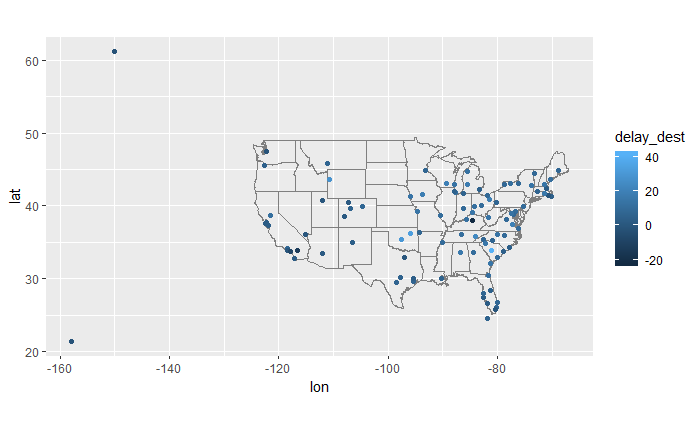

You might want to use the size or colour of the points to display the average delay for each airport.

Add the location of the origin and destination (i.e. the lat and lon) to flights.

| year | month | day | hour | origin | dest | lat.x | lon.x | lat.y | lon.y |
| --- | --- | --- | --- | --- | --- | --- | --- | --- | --- |
| 2013 | 1 | 1 | 5 | EWR | IAH | 40.69250 | -74.16867 | 29.98443 | -95.34144 |
| 2013 | 1 | 1 | 5 | LGA | IAH | 40.77725 | -73.87261 | 29.98443 | -95.34144 |
| 2013 | 1 | 1 | 5 | JFK | MIA | 40.63975 | -73.77893 | 25.79325 | -80.29056 |
| 2013 | 1 | 1 | 5 | JFK | BQN | 40.63975 | -73.77893 | NA | NA |
| 2013 | 1 | 1 | 6 | LGA | ATL | 40.77725 | -73.87261 | 33.63672 | -84.42807 |
| 2013 | 1 | 1 | 5 | EWR | ORD | 40.69250 | -74.16867 | 41.97860 | -87.90484 |
| 2013 | 1 | 1 | 6 | EWR | FLL | 40.69250 | -74.16867 | 26.07258 | -80.15275 |
| 2013 | 1 | 1 | 6 | LGA | IAD | 40.77725 | -73.87261 | 38.94453 | -77.45581 |
| 2013 | 1 | 1 | 6 | JFK | MCO | 40.63975 | -73.77893 | 28.42939 | -81.30899 |
| 2013 | 1 | 1 | 6 | LGA | ORD | 40.77725 | -73.87261 | 41.97860 | -87.90484 |

[output cut: 990 more lines]

Is there a relationship between the age of a plane and its delays?

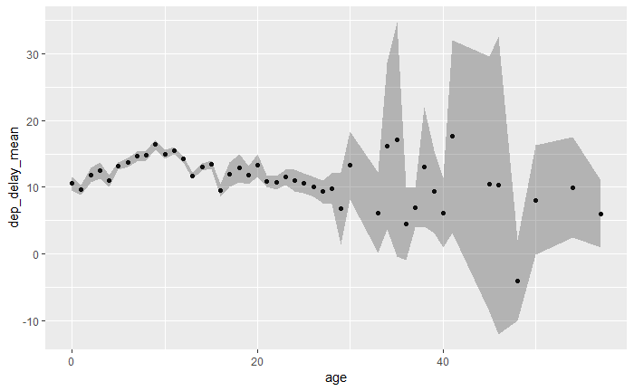

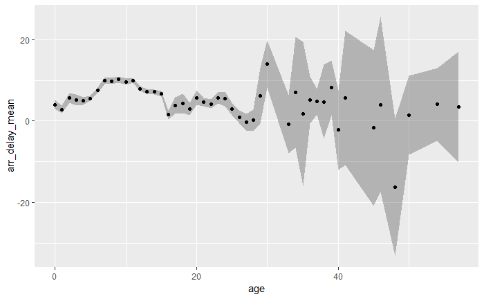

What weather conditions make it more likely to see a delay?

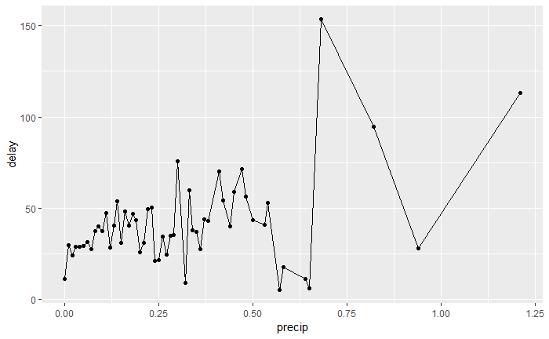

What happened on June 13 2013? Display the spatial pattern of delays, and then use Google to cross-reference with the weather.

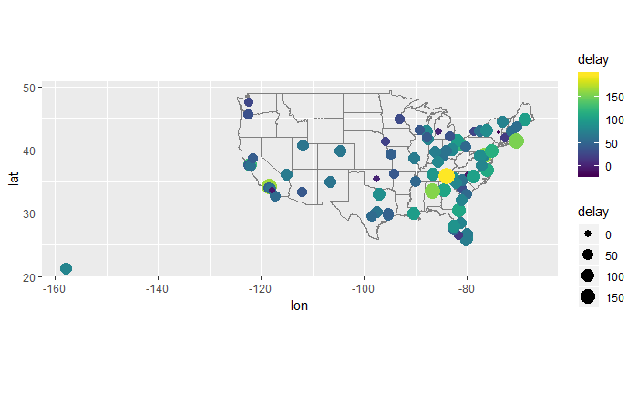

13.5.1

| year | month | day | dep_time | sched_dep_time | dep_delay | arr_time | sched_arr_time | arr_delay | carrier | flight | tailnum | origin | dest | air_time | distance | hour | minute | time_hour |
| --- | --- | --- | --- | --- | --- | --- | --- | --- | --- | --- | --- | --- | --- | --- | --- | --- | --- | --- |
| 2013 | 1 | 2 | NA | 1545 | NA | NA | 1910 | NA | AA | 133 | NA | JFK | LAX | NA | 2475 | 15 | 45 | 2013-01-02 15:00:00 |
| 2013 | 1 | 2 | NA | 1601 | NA | NA | 1735 | NA | UA | 623 | NA | EWR | ORD | NA | 719 | 16 | 1 | 2013-01-02 16:00:00 |
| 2013 | 1 | 3 | NA | 857 | NA | NA | 1209 | NA | UA | 714 | NA | EWR | MIA | NA | 1085 | 8 | 57 | 2013-01-03 08:00:00 |
| 2013 | 1 | 3 | NA | 645 | NA | NA | 952 | NA | UA | 719 | NA | EWR | DFW | NA | 1372 | 6 | 45 | 2013-01-03 06:00:00 |
| 2013 | 1 | 4 | NA | 845 | NA | NA | 1015 | NA | 9E | 3405 | NA | JFK | DCA | NA | 213 | 8 | 45 | 2013-01-04 08:00:00 |
| 2013 | 1 | 4 | NA | 1830 | NA | NA | 2044 | NA | 9E | 3716 | NA | EWR | DTW | NA | 488 | 18 | 30 | 2013-01-04 18:00:00 |
| 2013 | 1 | 5 | NA | 840 | NA | NA | 1001 | NA | 9E | 3422 | NA | JFK | BOS | NA | 187 | 8 | 40 | 2013-01-05 08:00:00 |
| 2013 | 1 | 7 | NA | 820 | NA | NA | 958 | NA | 9E | 3317 | NA | JFK | BUF | NA | 301 | 8 | 20 | 2013-01-07 08:00:00 |
| 2013 | 1 | 8 | NA | 1645 | NA | NA | 1838 | NA | US | 123 | NA | EWR | CLT | NA | 529 | 16 | 45 | 2013-01-08 16:00:00 |
| 2013 | 1 | 9 | NA | 755 | NA | NA | 1012 | NA | 9E | 4023 | NA | EWR | CVG | NA | 569 | 7 | 55 | 2013-01-09 07:00:00 |

[output cut: 990 more lines]

These flights didnt take off

| carrier | n |
| --- | --- |
| MQ | 25397 |
| AA | 22558 |
| UA | 1693 |
| 9E | 1044 |
| B6 | 830 |
| US | 699 |
| FL | 187 |
| DL | 110 |
| F9 | 50 |
| WN | 38 |

These two carriers dont seem t ohave tailnums

Filter flights to only show flights with planes that have flown at least 100 flights.

| year | month | day | dep_time | sched_dep_time | dep_delay | arr_time | sched_arr_time | arr_delay | carrier | flight | tailnum | origin | dest | air_time | distance | hour | minute | time_hour |
| --- | --- | --- | --- | --- | --- | --- | --- | --- | --- | --- | --- | --- | --- | --- | --- | --- | --- | --- |
| 2013 | 1 | 1 | 517 | 515 | 2 | 830 | 819 | 11 | UA | 1545 | N14228 | EWR | IAH | 227 | 1400 | 5 | 15 | 2013-01-01 05:00:00 |
| 2013 | 1 | 1 | 533 | 529 | 4 | 850 | 830 | 20 | UA | 1714 | N24211 | LGA | IAH | 227 | 1416 | 5 | 29 | 2013-01-01 05:00:00 |
| 2013 | 1 | 1 | 544 | 545 | -1 | 1004 | 1022 | -18 | B6 | 725 | N804JB | JFK | BQN | 183 | 1576 | 5 | 45 | 2013-01-01 05:00:00 |
| 2013 | 1 | 1 | 554 | 558 | -4 | 740 | 728 | 12 | UA | 1696 | N39463 | EWR | ORD | 150 | 719 | 5 | 58 | 2013-01-01 05:00:00 |
| 2013 | 1 | 1 | 555 | 600 | -5 | 913 | 854 | 19 | B6 | 507 | N516JB | EWR | FLL | 158 | 1065 | 6 | 0 | 2013-01-01 06:00:00 |
| 2013 | 1 | 1 | 557 | 600 | -3 | 709 | 723 | -14 | EV | 5708 | N829AS | LGA | IAD | 53 | 229 | 6 | 0 | 2013-01-01 06:00:00 |
| 2013 | 1 | 1 | 557 | 600 | -3 | 838 | 846 | -8 | B6 | 79 | N593JB | JFK | MCO | 140 | 944 | 6 | 0 | 2013-01-01 06:00:00 |
| 2013 | 1 | 1 | 558 | 600 | -2 | 849 | 851 | -2 | B6 | 49 | N793JB | JFK | PBI | 149 | 1028 | 6 | 0 | 2013-01-01 06:00:00 |
| 2013 | 1 | 1 | 558 | 600 | -2 | 853 | 856 | -3 | B6 | 71 | N657JB | JFK | TPA | 158 | 1005 | 6 | 0 | 2013-01-01 06:00:00 |
| 2013 | 1 | 1 | 558 | 600 | -2 | 923 | 937 | -14 | UA | 1124 | N53441 | EWR | SFO | 361 | 2565 | 6 | 0 | 2013-01-01 06:00:00 |

[output cut: 990 more lines]

Combine fueleconomy::vehicles and fueleconomy::common to find only the records for the most common models.

| id | make | model | year | class | trans | drive | cyl | displ | fuel | hwy | cty |
| --- | --- | --- | --- | --- | --- | --- | --- | --- | --- | --- | --- |
| 1833 | Acura | Integra | 1986 | Subcompact Cars | Automatic 4-spd | Front-Wheel Drive | 4 | 1.6 | Regular | 28 | 22 |
| 1834 | Acura | Integra | 1986 | Subcompact Cars | Manual 5-spd | Front-Wheel Drive | 4 | 1.6 | Regular | 28 | 23 |
| 3037 | Acura | Integra | 1987 | Subcompact Cars | Automatic 4-spd | Front-Wheel Drive | 4 | 1.6 | Regular | 28 | 22 |
| 3038 | Acura | Integra | 1987 | Subcompact Cars | Manual 5-spd | Front-Wheel Drive | 4 | 1.6 | Regular | 28 | 23 |
| 4183 | Acura | Integra | 1988 | Subcompact Cars | Automatic 4-spd | Front-Wheel Drive | 4 | 1.6 | Regular | 27 | 22 |
| 4184 | Acura | Integra | 1988 | Subcompact Cars | Manual 5-spd | Front-Wheel Drive | 4 | 1.6 | Regular | 28 | 23 |
| 5303 | Acura | Integra | 1989 | Subcompact Cars | Automatic 4-spd | Front-Wheel Drive | 4 | 1.6 | Regular | 27 | 22 |
| 5304 | Acura | Integra | 1989 | Subcompact Cars | Manual 5-spd | Front-Wheel Drive | 4 | 1.6 | Regular | 28 | 23 |
| 6442 | Acura | Integra | 1990 | Subcompact Cars | Automatic 4-spd | Front-Wheel Drive | 4 | 1.8 | Regular | 24 | 20 |
| 6443 | Acura | Integra | 1990 | Subcompact Cars | Manual 5-spd | Front-Wheel Drive | 4 | 1.8 | Regular | 26 | 21 |

[output cut: 990 more lines]

Find the 48 hours (over the course of the whole year) that have the worst delays. Cross-reference it with the weather data. Can you see any patterns?

What does anti_join(flights, airports, by = c(“dest” = “faa”)) tell you? What does anti_join(airports, flights, by = c(“faa” = “dest”)) tell you?

You might expect that there’s an implicit relationship between plane and airline, because each plane is flown by a single airline. Confirm or reject this hypothesis using the tools you’ve learned above.